# Predicting Movements in the Yen-Dollar Exchange Rate

Applied Regression Analysis Spring 2021, Project 2

Jarod Acanfrio

### **1. Introduction**

When many people think of finance and trading, their heads fill with thoughts of Wall Street, major banks, and trading stocks and options among other things. But what if the largest financial market in the world wasn’t stocks, options, or other products? In fact, the largest financial market in the world is FOREX, short for foreign exchange; the market where you can buy and sell currency. In 2019 alone more than $6.6 trillion was traded daily on the FOREX markets. (https://www.bloomberg.com/news/articles/2019-09-16/global-currency-trading-surges-to-6-6-trillion-a-day-market) In this project I explore a model to predict percentage change in FOREX rates of the Yen-Dollar currency pair, based on several derived features from macroeconomic data.

### **2. Hypothesis**

Starting upon this project, I thought to myself, “What may indicate swings in exchange rates?” After brief research four main classes of features were decided upon for forecasting exchange rate movements. I hypothesize that the following features will be significant in the regression for Yen-Dollar exchange rate movements.

1. Metric of Comparative Market Growth
2. Metric of Comparative Inflation
3. Metric of Comparative Production Output
4. Metric of Comparative Money Supply Changes

#### *Metric of Comparative Market Growth*

This feature represents the difference between the US stock market growth, and the Japanese stock market growth. I chose this because as markets grow, the currency the market is based on tends to strengthen in value. A feature relating these two countries’ growth of markets can help indicate which currency is growing stronger compared to the other, and may indicate movements in exchange rates.

#### *Metric of Comparative Inflation*

A common metric used to understand inflation in an economy is the Consumer Price Index (CPI), which measures the average cost of goods in a country. As the CPI percent increase over some time period rises we have inflation, and as it lowers we have deflation. Comparing the change in CPI of the United States and Japan will help us understand which economy is experiencing more inflation, which weakens the value of their currency relative to the other.

#### *Metric of Comparative Production Output*

Another useful metric for understanding how an economy is functioning is the Gross Domestic Product (GDP). The GDP measures the market value of produced goods in an economy; it is a strong indicator of economic health. Comparing the percentage change of each countries’ GDP we can infer which economy is growing relative to the other. The economy with greater growth should see its currency strengthen against the others.

#### *Metric of Comparative Money Supply Changes*

In an economy the money supply is the value of all currency in circulation. As an economic stimulus, governments will print and pump money into circulation; something we have seen recently in an attempt to stabilize the COVID-era economy. Rapid increases in the amount of money in circulation tend to lead to an increase in inflation. Looking at the Equation of Exchange we can see how money supply is linearly related to prices in an economy. We can directly relate how changes in money supply cause changes in price, a prime indicator of inflation. As the currency experiences inflation, it will weaken relative to the other currency. I compare the increase of money supply in each country to see which currency should experience more inflation; this metric is the last feature in my model.

#### *Formal Statement of Hypothesis*

$$\begin{align*}
H_0: &\left(\forall i \in [1,2,3,4]\right)\left(\beta_i = 0\right)\\
H_1: &\left(\exists i \in [1,2,3,4]\right)\left(\beta_i \ne 0\right)\\
\end{align*}$$
My null hypothesis is that none of the features have a significant effect on the Yen-Dollar exchange rate, they all have coefficients equal to zero. My alternative hypothesis is that there exists some feature coefficient which is non-zero, indicating that the variable is significant for predicting the Yen-Dollar exchange rate.

### **3. Data**

To calculate the features I described above, I need eight macroeconomic variables. All of the data used in this project is free, and publicly available from the St. Louis Federal Reserve Economic Database (FRED). Each variable has an associated code in the database; I have included them here in case anyone would like to explore the data on their own. My variables used are:

- United States Real GDP (GDPC1)
- Japan Real GDP (JPNRGDPEXP)
- NASDAQ Composite Index (NASDAQCOM)
- Nikkei 225 Index (NIKKEI225)
- United States CPI (CPIAUCSL)
- Japan CPI (JPNCPIALLMINMEI)
- United States M1 Money Supply (M1SL)
- Japan M1 Money Supply (MANMM101JPM189S)

The dependent variable in this study is the Yen-Dollar exchange rate (EXJPUS). Given that financial time-series exhibit trend, we cannot use the raw values of these variables in the study. Instead I opt for the percent change in the value of the variable over the prior year. Percentage changes in time-series have been shown to be stationary, it does not follow some underlying trend, making them a good choice for regression analysis. Using the percent change over the prior year also allows me to understand the trend in the feature; these values give us an idea of growth or shrinkage of the feature over the past year. I choose percent change over the year as opposed to other shorter time frames because it is long enough to capture a general trend, but not short enough to pick up a lot of noise in short term volatility.

### **4. Pre-Processing**

After gathering the data from the FRED database, I needed to process it, and put it into a format that was usable. There was a few issues with the data after first downloading it:

- Missing data points, due to markets not reporting on certain holidays or other days is represented as a “.” in the data. These points need to be converted to “NA” so we have a numeric vector instead of a character vector.
- Features are reported on different time frames, we need to put them all on the same scale:
  - NASDAQ and Nikkei 225 closing values are reported daily.
  - Consumer Price Index, M1 Money Supply, and Yen-Dollar exchange rates are reported monthly.
  - GDP is reported quarterly
- Several data sets on different time scales need to be joined together.
- After joining data, we need to interpolate on the missing values due to time differences.

Below I highlight the main pre-processing functions.

#### *Missing Data Conversions*

As mentioned above we need to clean each column of our data and convert any missing points. To do this I wrote a function “clean_columns()”:

```r
# Clear environment and set directory
rm(list = ls())
setwd("C:/Users/acanfj/Dropbox/spring_2021/Applied Regression Analysis/Applied Regression Analysis Projects/Acanfrio_Jarod_Project_2")
cat("\014")
```

```r
set.seed(8211999)

# Library imports
library("tidyverse")
library("skedastic")
library("zoo")
library("car")

# ------------------------------------------------------------------------------
# clean_columns(df)
#
# Input: df
#   A data frame or tibble to clean missing values (.) from. Will replace with NA
#
# Output: df
#   A tibble of cleaned columns with only numeric data and NA. The output is
#   expected to be fed into a cubic spline interpolation to remove NA values.
#   Operations performed in place to speed up computation.
#
clean_columns <- function(df){

  # In-place mutations for speed
  for(i in 2:ncol(df)){
    df[, i] <- dplyr::na_if(df[,i], ".")
  }

  # Convert df to a tibble of numeric columns
  df <- df %>%
          tibble::as_tibble() %>%
          mutate_all(type.convert) %>%
          mutate_if(is.character, as.numeric)

  # Return cleaned df
  df
}
```

#### *Merge Multiple Data Frames*

To merge all of the data frames in the project I wrote a function “merge_df_set()”. I decided to join all tables onto the Monthly table, as that is the sampling rate of our dependent variable in the study. I do not want to interpolate values of what I am trying to predict. It is also the sampling rate of the majority of the variables in the study.

```r
#-------------------------------------------------------------------------------
# merge_df_set(df.list)
#
# Input: df.list
#   A list composed of cleaned data frames or tibbles
#   Assumes first data frame or tibble to join_left on is in index 1
#   Assumes first column in each data frame or tibble is DATE
#
# Output: df
#   A tibble of all variables merged together.
#
merge_df_set <- function(df.list){

    # Get our first data frame in the passed in list
    temp.df <- df.list[[1]]

    # For all remaining data frames, join them onto the existing data frame
    for(i in 2:(length(df.list))){

      # Join our variables on the date to align samples
      temp.df <- dplyr::left_join(temp.df, df.list[[i]], by = "DATE")
    }

    # Set output as merged data frame, and return
    df <- temp.df
    df
}
```

#### *Interpolate NA Values in Data Frame*

After merging our data frames, features that are sampled less frequently than the table we initially joined on will have Na values throughout the column. To eliminate these “NA” values, I use cubic spline interpolation to fill them in. Cubic spline interpolation was chosen over linear interpolation due to my assumption that the data at this point is non-linear. I cannot assume that it would follow a linear pattern to the next point; financial data is messy and complex - the linear assumption is too simple.

```r
#-------------------------------------------------------------------------------
# interpolate_columns(df)
#
# Input: df
#     A data frame or tibble of numeric values with some NA's present. Using the
#     zoo package I use cubic spline interpolation to convert the NA values to
#     numeric estimates
#
# Output: df.return
#     A tibble of cleaned, interpolated numeric values
#
interpolate_columns <- function(df){

  # For all columns except DATE
  for(i in 2:ncol(df)){

    # Interpolate at a maximum of 100 continuous NA values
    df[,i] <- zoo::na.spline(df[,i], maxgap = 100, na.rm = FALSE)
  }

  # Return data frame
  df
}
```

#### *Lagging the Financial Data*

A main point of financial time-series modeling is to not only understand the relationship between several factors, but to also predict how a response will move based on a set of factors. In order to do this we need to lag our response by some number of periods, $n$. Using the features recorded at time $t$ to predict the response at time $t$ doesn’t help us predict; we already know the value of the response. Below is my function to lag the response on the features:

```r
#-------------------------------------------------------------------------------
# lag_data(df, nper.lag)
#
# Input
#   df:
#     A data frame of values to be lagged a certain set of time periods
#
#   nper.lag:
#     The number of periods to lag the data by.
#
# Output
#
#   df.lagged:
#     A data frame of lagged values
#
lag_data <- function(df, nper.lag, response){

  # Determine number of samples in data frame
  # Create empty tibble to fill with values
  # Declare vector to fill with lagged values
  n = nrow(df)
  df.lagged <- tibble::tibble(.rows = n - nper.lag)
  lagged.vec <- NULL

  for(i in 2:ncol(df)){

    # Get name of feature being lagged
    var.name <- names(df)[i]

    # If-else to determine how to lag variable
    # Response is lagged forward, features are lagged backward
    if(var.name == response){
      lagged.vec <- df[var.name][(1+nper.lag):n,]
    }
    else{
      lagged.vec <- df[var.name][1:(n-nper.lag),]
    }

    # Append lagged column to output data frame
    df.lagged <- df.lagged %>% tibble::add_column(lagged.vec)
  }

  # Return data frame
  df.lagged
}
```

#### *Calculating the Model Features*

As mentioned above in section 2, we need comparative features between the United States and Japan. Currently, we have features for each country, but they don’t tell us how the two economy’s compare. To create the features that compare the US and Japan, I look at the spread in percentage change for each of the feature sets. For example, to compare the GDP growths I calculate the spread of US growth and Japanese growth. High values of this spread indicate that the US GDP grew more than Japan’s GDP, and vice-versa. This logic holds for all features. Below is the function I wrote to compute my final features for the model:

```r
#-------------------------------------------------------------------------------
# calculate_features(df)
#
# Input: df
#     A data frame of variables to compute features from
#
# Output: df.features
#     A data frame of computed features
#
calculate_features <- function(df){

  # Calculate GDP Spreads
  gdp_growth_spread <- df$GDPC1_PC1 - df$JPNRGDPEXP_PC1

  # Calculate Market Growth Spread
  market_growth_spread <- df$NASDAQCOM_PC1 - df$NIKKEI225_PC1

  # Calculate CPI Change Spread
  cpi_change_spread <- df$CPIAUCSL_PC1 - df$JPNCPIALLMINMEI_PC1

  # Calculate M1 Money Supply Change Spread
  m1_change_spread <- df$M1SL_PC1 - df$MANMM101JPM189S_PC1

  # JPY-USD Exchange Rate
  exchange_rate <- df$EXJPUS_PC1

  # Create output data frame of all computed features
  df.features <- tibble::tibble("exchange.rate" = exchange_rate,
                                "gdp.growth.spread" = gdp_growth_spread,
                                "market.growth.spread" = market_growth_spread,
                                "cpi.growth.spread" = cpi_change_spread,
                                "m1.growth.spread" = m1_change_spread)

  # Return data frame of features
  df.features
}
```

#### *Feeding the Data Through the Pre-Processing Pipeline*

After defining all of our functions I can pass my data through the pipeline to get my data frame to be used in model development. This concludes the pre-processing stage.

```r
# Load data
daily.df <- readr::read_csv("exchangerate1yr/Daily_Close.csv")
monthly.df <- readr::read_csv("exchangerate1yr/Monthly.csv")
quarterly.df <- readr::read_csv("exchangerate1yr/Quarterly.csv")

# Convert FRED API missing values to NA
daily.df <- daily.df %>% clean_columns()
monthly.df <- monthly.df %>% clean_columns()
quarterly.df <- quarterly.df %>% clean_columns()

# Aggregate the cleaned data frames / tibbles into a list
cleaned.df.list <- list(monthly.df, daily.df, quarterly.df)

# Lag data by a number of period
nper.lag = 2

# Pass data through pipeline to get final data frame
# NOTE: dplyr::slice() used to remove 2020 data points.
#       These values were extreme outliers due to COVID
#       and it was decided that removing them would allow
#       for the best analysis. COVID was a severe event that
#       put markets into abnormal conditions.
df <- cleaned.df.list %>%
      merge_df_set() %>%
      interpolate_columns() %>%
      lag_data(nper.lag, response = "EXJPUS_PC1") %>%
      dplyr::slice(1:312) %>%
      calculate_features()

# Sanity check on cleaned data
for(i in 2:ncol(df)){
  if(sum(!is.na(df[,i])) != nrow(df[,i])){
    cat("NA found in column ", names(df)[i])
  }
}

print(head(df))
```

| exchange.rate | gdp.growth.spread | market.growth.spread | cpi.growth.spread | m1.growth.spread |
| --- | --- | --- | --- | --- |
| -10.18652 | 69.17735 | 38.72510 | 1.20228 | 5.33923 |
| -7.94145 | 58.18311 | -5.72976 | 1.37227 | 4.73028 |
| -5.97201 | 48.40053 | -3.51192 | 1.30323 | 4.05666 |
| -4.54829 | 39.76289 | 15.60672 | 1.54050 | 3.06982 |
| -8.58602 | 32.20394 | 15.30185 | 1.46544 | 2.46988 |
| -3.68583 | 25.65928 | 2.45533 | 1.97987 | 1.55249 |

### **5. Building the Model**

#### *Initial Data Analysis*

After creating our data frame of features, the next step is analyzing them. I first look at the correlation matrix of all features and the response, to look for strong correlations between features and response, and low correlations among the features themselves.

```r
# Generate correlation matrix
print(cor(df))
```

```
                     exchange.rate gdp.growth.spread market.growth.spread cpi.growth.spread m1.growth.spread
exchange.rate            1.0000000       -0.13646024          -0.33806902       -0.17964649      -0.17001538
gdp.growth.spread       -0.1364602        1.00000000           0.08835199       -0.13454960       0.05446056
market.growth.spread    -0.3380690        0.08835199           1.00000000        0.03559655      -0.07956094
cpi.growth.spread       -0.1796465       -0.13454960           0.03559655        1.00000000      -0.24585137
m1.growth.spread        -0.1700154        0.05446056          -0.07956094       -0.24585137       1.00000000
```

We see that market.growth.spread is the highest correlated feature to the exchange rate movements. The other features have a correlation in the range of $\rho \in [-0.17,-0.13]$.

*Correlation Results and How They Relate to Financial Theory*

At this point I compare the correlation results between the features and the response and see how they align to financial theory.

*Interpreting Exchange Rate Change Over the Prior Year*

Let’s consider the following example:

- Exchange Rate in Year 1: 100 Yen to 1 US Dollar
- Exchange Rate in Year 2: 90 Yen to 1 US Dollar

The percent change over one year is:
$$\Delta_{1Y}EXRATE = \frac{EXRATE_2 - EXRATE_1}{EXRATE_1} = \frac{90-100}{100} = -0.1$$
That is, the exchange rate decreased by ten percent. One dollar went from equaling 100 Yen, to 90 Yen. We can interpret this as the Yen strengthened against the Dollar. If the conversion rate were 1:1, the Yen would be as powerful as the Dollar. In this study decreasing exchange rates indicate that the Yen is strengthening, and vice-versa.

*Interpreting GDP Spread Correlation to Exchange Rate Change*

We have defined our GDP spread as:
$$\Delta GDP = \Delta_{1Y}GDP_{US} -\Delta_{1Y}GDP_{JP}$$
Positive values indicate that the United States had a higher increase in GDP than Japan. As a result of this economic growth, the US dollar in theory should strengthen. From the above example a strengthening US dollar relative to the Yen should cause a positive increase in the exchange rate over the prior year. Our correlation coefficient here is $\rho = -0.1364602$. This indicates that as the US has a greater GDP than Japan, the Yen actually strengthens against the dollar. This does not make theoretical sense. I look at the plot of Exchange Rate Percentage Change over the past year vs. GDP spread to look for any trends or outliers.

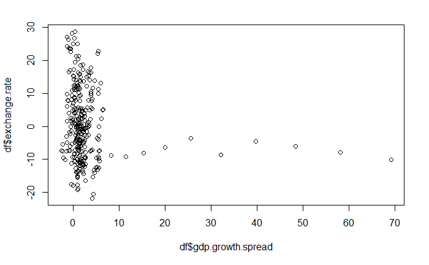

```r
plot(df$gdp.growth.spread, df$exchange.rate)
```

Clearly there is no relationship here, and I suspect the slight correlation is heavily influenced by the outlier spreads greater than 10. At this point I discard the GDP spread from the analysis.

*Interpreting Market Growth Spread Correlation to Exchange Rate Change*

We have defined our Market Growth spread as:
$$\Delta MKT = \Delta_{1Y}MKT_{US} -\Delta_{1Y}MKT_{JP}$$
Positive values mean that the United States Market grew more than Japan’s over the last year. The correlation of this feature to the exchange rate movement is $\rho = -0.3380690$; it has the highest correlation to the response among all features. Again this feature indicates that as the US market outperforms the Japanese market, the Yen strengthens against the dollar. Looking at the plot below there does appear to be some downward trend in the data. I suspect I may be missing something in my explanation for how Market growth spreads would affect the exchange rate, and keep the variable for the analysis.

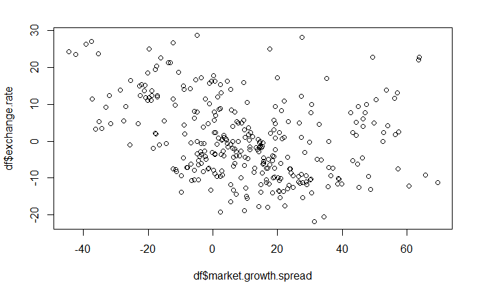

```r
plot(df$market.growth.spread, df$exchange.rate)
```

*Interpreting CPI Growth Spread Correlation to Exchange Rate Change*

We have defined our Market Growth spread as:
$$\Delta CPI = \Delta_{1Y}CPI_{US} -\Delta_{1Y}CPI_{JP}$$
Positive values mean that the United States faced more inflation than Japan over the last year. The correlation of this feature to the exchange rate movement is $\rho = -0.1796465$. This indicates that as the US saw more inflation than Japan that the Yen strengthened against the US dollar. This makes sense; as the US dollar is being inflated, it would grow weaker to the Yen, swinging the exchange rate in favor of the Yen. Looking at the graph, we see a slight downward trend, but nothing very strong. Given that the sign of the correlation makes sense with our theory we keep the feature in the model.

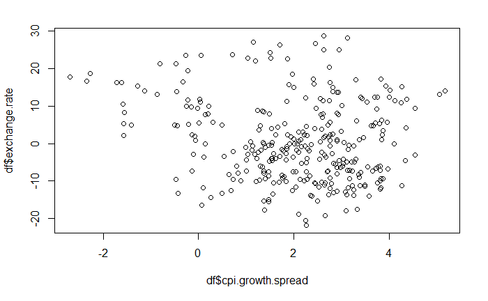

```r
plot(df$cpi.growth.spread, df$exchange.rate)
```

*Interpreting M1 Growth Spread Correlation to Exchange Rate Change*

We have defined our Market Growth spread as:
$$\Delta M1 = \Delta_{1Y}M1_{US} -\Delta_{1Y}M1_{JP}$$
Positive values mean that the United States introduced more money than Japan into circulation over the last year. The correlation of this feature to the exchange rate movement is $\rho = -0.1700154$. This indicates that as the US printed more money over a year than Japan, that the Yen strengthened against the dollar. This makes sense; introducing more money weakens the value of the dollar, swinging the exchange rate in favor of the Yen. We plot the feature against the response and again see some cluster with downward trend but nothing too significant. We keep the variable in our analysis.

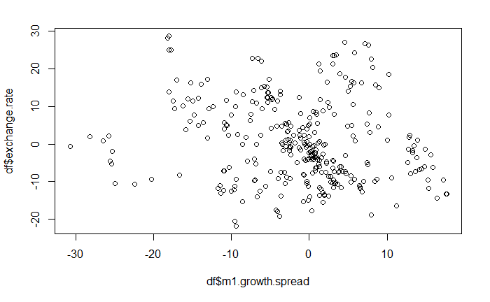

```r
plot(df$m1.growth.spread, df$exchange.rate)
```

*Determining the Sample Size for Model Fitting*

I use G-Power to calculate the size of the sample to fit the model to. I select the “Linear Multiple Regression: Fixed Model, $R^2$ Deviation From Zero” test from the family of F tests. My input parameters and reasoning for what they are set to are as follows:

- Effect Size: $0.1$
  - An effect size of $0.1$ is between small and medium. I don’t expect these features to explain all of the variance in the exchange rates, but I do think they will contribute to some of it. Exchange rate movements are complex, being affected by social, economic, and political factors; we cannot reduce an exchange rate or its behavior down to a few macroeconomic variables. Using my three features is a gross simplification, but makes for an interesting study.
- $\alpha$: $0.01$
  - I chose a smaller probability of Type 1 error, because of the implications this model could have. Suppose the model proves very effective at predicting exchange rate movements. This model could be incorporated into some type of FOREX trading strategy. With real money on the line we would not want to reject the null in favor of the alternative; we would be sure to lose money.
- Power: $0.8$
  - I chose a power of $0.8$, because I think rejecting the null and being correct 80% of the time is enough. If we had strong theoretical evidence that the null was true but our experiment said otherwise, we could always re-test, or investigate further. Perhaps the sample has some extreme outliers and caused the output to be misleading.

As a result of the Power Analysis we see that we need 161 data points in our model fitting sample.

```r
#Select subset of data for model fitting
df <- df %>% dplyr::sample_n(size = 161)
```

*Building the Model*

Based on the above analysis the model will be built using the Market Growth Spread, the CPI Growth Spread, and the M1 Money Supply Growth Spread. The variable entry procedure will be Hierarchical, in order of highest correlation to the exchange rate movement to lowest. The following code builds our model:

```r
exchange.rate.lm <- lm(exchange.rate ~ market.growth.spread +
                                       cpi.growth.spread +
                                       m1.growth.spread,
                                       data = df)
print(summary(exchange.rate.lm))
```

```
Call:
lm(formula = exchange.rate ~ market.growth.spread + cpi.growth.spread +
    m1.growth.spread, data = df)

Residuals:
     Min       1Q   Median       3Q      Max
-20.4729  -6.0052  -0.3963   6.0858  27.2740

Coefficients:
                     Estimate Std. Error t value Pr(>|t|)
(Intercept)           6.19350    1.28879   4.806 3.58e-06 ***
market.growth.spread -0.19505    0.03572  -5.461 1.81e-07 ***
cpi.growth.spread    -2.10697    0.53146  -3.964 0.000111 ***
m1.growth.spread     -0.31269    0.08425  -3.711 0.000286 ***
---
Signif. codes:  0 ‘***’ 0.001 ‘**’ 0.01 ‘*’ 0.05 ‘.’ 0.1 ‘ ’ 1

Residual standard error: 9.291 on 157 degrees of freedom
Multiple R-squared:  0.2636,    Adjusted R-squared:  0.2496
F-statistic: 18.74 on 3 and 157 DF,  p-value: 1.936e-10
```

*Model Output Summary and Analysis*

The model output summary shows that all variables are significant at the level $\alpha = 0.001$. Despite this high level of significance, our $R^2$ value is very low. My first thought is that multicollinearity is affecting the parameter estimates and is causing untrue significance to be shown. To test for this I run a series of regressions, regressing two of the features onto the third. I check the variance inflation factor for each model. I will use a strict cutoff of 5 for the VIF, as I expect strong multicollinearity within the model.

*Multicollinearity Test*

```r
# VIF Checks
market.growth.lm <- lm(market.growth.spread ~ cpi.growth.spread +
                                              m1.growth.spread,
                                              data = df)
print(summary(market.growth.lm))
```

```
Call:
lm(formula = market.growth.spread ~ cpi.growth.spread + m1.growth.spread,
    data = df)

Residuals:
    Min      1Q  Median      3Q     Max
-49.660 -12.444   0.134  11.854  56.836

Coefficients:
                  Estimate Std. Error t value Pr(>|t|)
(Intercept)        7.00716    2.81610   2.488   0.0139 *
cpi.growth.spread  1.25442    1.17959   1.063   0.2892
m1.growth.spread  -0.03038    0.18765  -0.162   0.8716
---
Signif. codes:  0 ‘***’ 0.001 ‘**’ 0.01 ‘*’ 0.05 ‘.’ 0.1 ‘ ’ 1

Residual standard error: 20.7 on 158 degrees of freedom
Multiple R-squared:  0.00838,   Adjusted R-squared:  -0.004172
F-statistic: 0.6676 on 2 and 158 DF,  p-value: 0.5144
```

```r
print(car::vif(market.growth.lm))
```

```
cpi.growth.spread  m1.growth.spread
         1.071585          1.071585
```

```r
cpi.growth.lm <- lm(cpi.growth.spread ~ market.growth.spread +
                                        m1.growth.spread,
                                        data = df)
print(summary(cpi.growth.lm))
```

```
Call:
lm(formula = cpi.growth.spread ~ market.growth.spread + m1.growth.spread,
    data = df)

Residuals:
    Min      1Q  Median      3Q     Max
-4.3968 -0.5249  0.2122  0.9126  2.4411

Coefficients:
                      Estimate Std. Error t value Pr(>|t|)
(Intercept)           1.885509   0.121320  15.542  < 2e-16 ***
market.growth.spread  0.005665   0.005327   1.063  0.28921
m1.growth.spread     -0.040652   0.012190  -3.335  0.00106 **
---
Signif. codes:  0 ‘***’ 0.001 ‘**’ 0.01 ‘*’ 0.05 ‘.’ 0.1 ‘ ’ 1

Residual standard error: 1.391 on 158 degrees of freedom
Multiple R-squared:  0.07343,   Adjusted R-squared:  0.06171
F-statistic: 6.261 on 2 and 158 DF,  p-value: 0.002417
```

```r
print(car::vif(cpi.growth.lm))
```

```
market.growth.spread     m1.growth.spread
            1.001284             1.001284
```

```r
m1.growth.lm <- lm(m1.growth.spread ~ market.growth.spread +
                                      cpi.growth.spread,
                                      data = df)
print(summary(m1.growth.lm))
```

```
Call:
lm(formula = m1.growth.spread ~ market.growth.spread + cpi.growth.spread,
    data = df)

Residuals:
     Min       1Q   Median       3Q      Max
-29.3564  -2.8555   0.6171   4.0726  18.9145

Coefficients:
                      Estimate Std. Error t value Pr(>|t|)
(Intercept)           2.177054   1.204590   1.807  0.07262 .
market.growth.spread -0.005459   0.033723  -0.162  0.87160
cpi.growth.spread    -1.617620   0.485064  -3.335  0.00106 **
---
Signif. codes:  0 ‘***’ 0.001 ‘**’ 0.01 ‘*’ 0.05 ‘.’ 0.1 ‘ ’ 1

Residual standard error: 8.774 on 158 degrees of freedom
Multiple R-squared:  0.06696,   Adjusted R-squared:  0.05515
F-statistic: 5.669 on 2 and 158 DF,  p-value: 0.00419
```

```r
print(car::vif(m1.growth.lm))
```

```
market.growth.spread    cpi.growth.spread
            1.008284             1.008284
```

Interestingly enough, all variance inflation factors are around $1.05\pm 0.05$. This tells me multicollinearity is not present within the model. The features appear to be significant but do not explain the whole picture for the movements in exchange rates. This satisfies our assumption that no predictors are linear combinations of others.

*Mean Error Equals Zero Assumption Test*

Moving onto the analysis of model output plots, I first plot the residuals as a function of the fitted model. This will test our assumption that the mean of the error term is 0, that is our response is a linear function of the predictors.

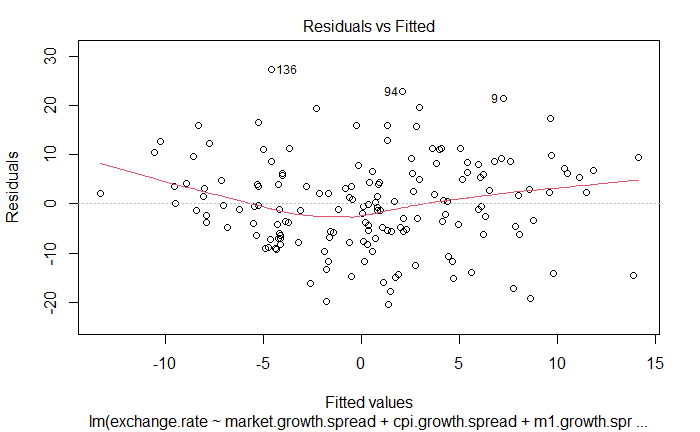

```r
plot(exchange.rate.lm, which = 1)
```

The residuals remain around 0, with some variation and a few outliers. There is slight deviation from 0 around the tail ends of the fitted values. We can check the mean value of the model residuals using the mean function in R;

```r
cat("The mean value of the residuals is : ", mean(exchange.rate.lm$residuals))
```

```
The mean value of the residuals is :  4.253817e-16
```

Being to the order of $10^{-16}$ we see that our assumption about the residuals is satisfied.

*Test Assumption that Predictors are Uncorrelated with Residuals*

I next test our assumption that the predictors and residuals are not correlated. To do this I can calculate the correlations with the R cor() function:

```r
cat("Correlation of market.growth.spread with the residuals : ",
    cor(exchange.rate.lm$residuals, df$market.growth.spread), "\n")
```

```
Correlation of market.growth.spread with the residuals :  2.107369e-17
```

```r
cat("Correlation of cpi.growth.spread with the residuals : ",
    cor(exchange.rate.lm$residuals, df$cpi.growth.spread), "\n")
```

```
Correlation of cpi.growth.spread with the residuals :  -5.972706e-18
```

```r
cat("Correlation of m1.growth.spread with the residuals : ",
    cor(exchange.rate.lm$residuals, df$m1.growth.spread), "\n")
```

```
Correlation of m1.growth.spread with the residuals :  5.028334e-17
```

The correlations of the features with the response is to the order of $10^{-17},10^{-18}$ This satisfies the assumption that our predictors and errors are not correlated.

*Test For Normality of Residuals*

To test our assumption of Normally distributed errors, we can check our QQ-plot:

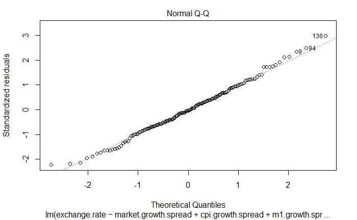

```r
plot(exchange.rate.lm, which = 2)
```

We see that the standardized residuals follow the quantile-quantile plot closely through the range $[-2.5, 2.5]$. Past these bounds, the residuals deviate from the line a bit. We see that around the expected quantile of $-2.5$ our residual is less than expected, being around $-2$, and that it deviates briefly around the theoretical standardized value of $2$, being closer to $2.25$. For the most part our residuals are normally distributed, but further tests should be run to obtain a p-value in order to better say if the assumption is satisfied.

*Test Assumption that Residuals Have Constant Variance*

Again, we go to the Residual vs. Fitted plot to examine how the variance in errors changes, if at all, with an increase in the response.

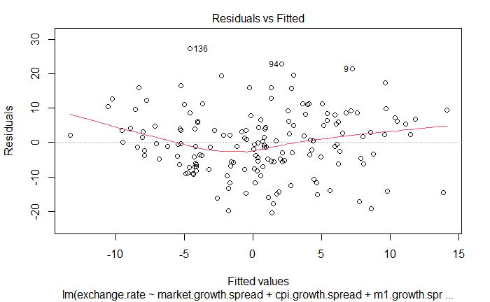

```r
plot(exchange.rate.lm, which = 1)
```

The residuals appear to have a tighter grouping with fitted values in the range $[-10, -5]$, but then the variance appears to stabilize for the remainder of the plot. There may some degree of heteroskedasticity in the model; to check further we run White’s test:

```r
print(skedastic::white_lm(exchange.rate.lm))
```

| statistic | p.value | parameter | method | alternative |
| --- | --- | --- | --- | --- |
| 17.42773 | 0.007833368 | 6 | White's Test | greater |

According to our test, heteroskedasticity is present in the model and is significant at the level $\alpha = 0.01$. The model violates our assumption of constant variance. Perhaps a variable transform could be used to fix this issue, but performing these transformations is outside the scope of this project.

*Introduction of Measurement Error*

I suspect there is some measurement error in the data, as I used interpolation to fill missing values when joining the data sampled quarterly onto the data frame sampled monthly. We used estimated values as two-thirds of the data for points sampled quarterly; for every quarterly sample two months between points were NA after the join. Clearly this introduces some form of error into the model.

Access to quality data was a limitation of this project. Unlike major funds and banks who pay thousands of dollars a year for high quality data from exchanges and other financial services companies, I used data from a public Federal Reserve database. I am tied to using data sampled at whatever rate they provide, and have to engineer it to the best of my ability to put it into a usable form. Had I had access to higher quality data I would’ve liked to perform this study on a weekly sampling rate.

### **7. Analysis and Conclusions**

Running a full analysis of the Yen-Dollar Exchange Rate model, we see that all but the heteroskedasticity of the residual assumptions are met. I believe that using a variable transform somewhere in the model will resolve the issue of heteroskedasticity. The derived features for CPI and M1 spreads are in line with financial theory; the derived feature for the Market Growth spread was not intuitive in terms of correlation with the response which leads me to believe my understanding of its relation to exchange rate spreads is incomplete to some degree. In the model summary it is shown that all of our features are significant at the level of $\alpha = 0.001$, yet we have not explained all of the variance in the exchange rate movements seeing as our $R^2 = .2636$. Based on the significance of the features I reject the null hypothesis in favor of the alternative, but am hesitant in doing so as a result of the heteroskedasticity. Had additional assumptions failed, I would reject the significance of the model.

These results give me confidence that the selected features hold some explanatory power for predicting how the exchange rate will increase over the prior year two months out into the future. The $R^2$ value is lower than I was hoping to see, but I am not entirely surprised. Financial markets are not the same as physical processes where certain features and values can be rigorously tied back to the response in question. Foreign exchange markets have many influences, and can be shocked at any time. This work was an attempt to simplify the phenomena of exchange rate movements down to a few simple spreads in macroeconomic variables of the countries with respect to the currency pair. I am very interested in exploring related work to this in the future.